# Crest y Colgate

José María Álvarez Silva

21/11/2019

CUNEF - Master en Data Science para Finanzas Predicción

# Propósito

Predicción del *Market Share* de crest y colgate. El objetivo es predecir las 16 semanas del año 1963, para las dos cuotas de mercado, tomando en cuenta el evento del ADA (1 de agosto de 1960, el Consejo de Terapéutica Dental de la American Dental Association (ADA) aprobó a Crest como una “ayuda importante en cualquier programa de higiene dental”). Este evento parece afectar la participación de mercado de ambos competidores por lo que es importante tenerlo en cuenta a la hora de predecir. La predicción se realizó con modelos ARIMA. Adicionalmente, un modelo de función de tranferencia entre las dos cuotas.

# Predicción

Se llevo a cabo la predicción de la participación de mercado de Crest y Colgate para las próximas 16 semanas. La predicción de Crest:

| 1963 | MS | MS | MS | MS |
| --- | --- | --- | --- | --- |
| 1-4 | 0.387001 | 0.395869 | 0.376461 | 0.391011 |
| 5-8 | 0.387204 | 0.388488 | 0.385771 | 0.387830 |
| 9-12 | 0.387281 | 0.387468 | 0.387088 | 0.387377 |
| 13-16 | 0.387298 | 0.387325 | 0.387272 | 0.387313 |

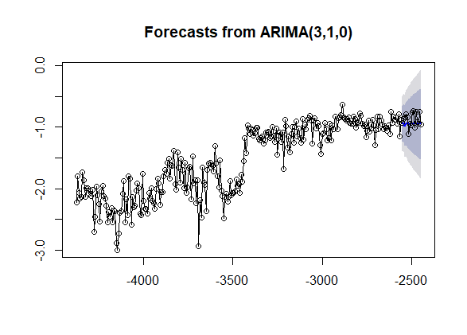

El modelo utilizado fue un modelo “ARIMA(3,1,0)” sobre el *Market Share* de Crest. (escala logarítmica)

La predicción de Colgate:

| 1963 | MS | MS | MS | MS |
| --- | --- | --- | --- | --- |
| 1-4 | 0.264273 | 0.264273 | 0.264273 | 0.264273 |
| 5-8 | 0.264273 | 0.264273 | 0.264273 | 0.264273 |
| 9-12 | 0.264273 | 0.264273 | 0.264273 | 0.264273 |
| 13-16 | 0.264273 | 0.264273 | 0.264273 | 0.264273 |

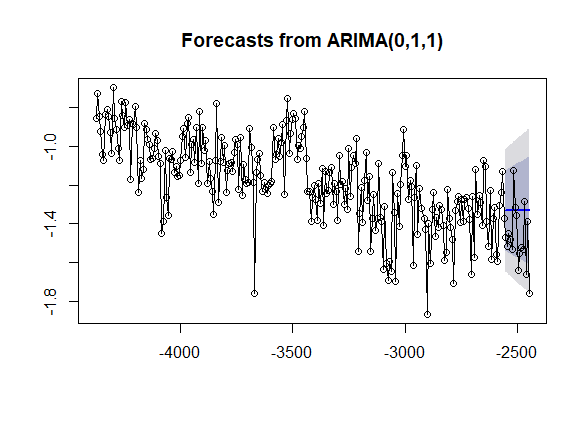

El modelo utilizado fue un modelo “ARIMA(0,1,1)” sobre el *Market Share* de Colgate. (escala logarítmica)

# Resumen Ejecutivo

## Proceso General

En este análisis utilizamos dos enfoques para la predicción del *Market Share* de las siguientes 16 semanas de **Crest** y **Colgate**. Se trabajó con el logaritmo de las series de tiempo del *Market Share* semanal de cada compañía desde 1958 a 1963. Los enfoques utilizados para predicir:

- ARIMA.
- ARIMAX - ARIMA con intervención.

## Resultados

Para tomar encuenta ADA se realizara un ajuste al modelar cada serie introduciendo una intervencion de tipo step:

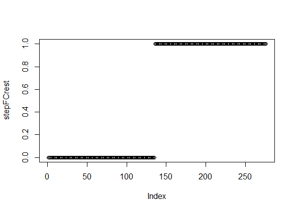

### CREST

[output not shown]

**Ajuste ARIMA**

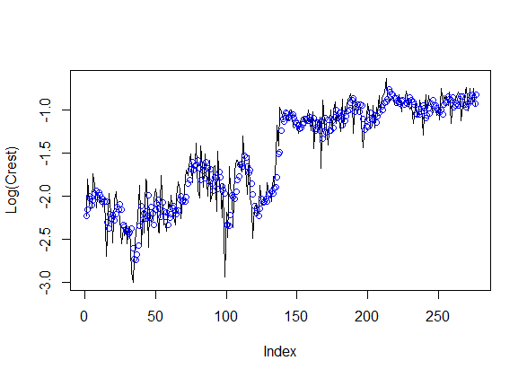

**Ajuste ARIMA con intervención**

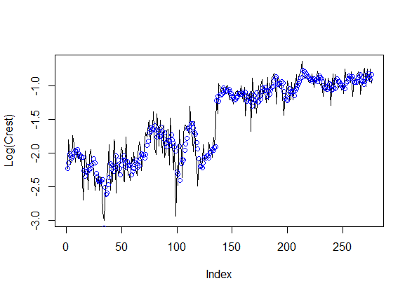

### COLGATE

[output not shown]

**Ajuste ARIMA**

[figure not shown]

**Ajuste ARIMA con intervención**

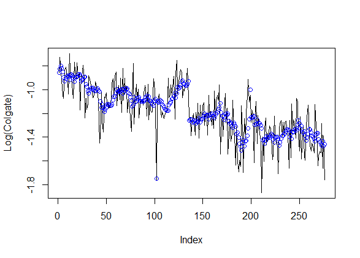

## Predicción

### Predicción Crest

Se llevo a cabo la predicción de la participación de mercado de Crest para las próximas 16 semanas. La predicción de Crest:

| 1963 | MS | MS | MS | MS |
| --- | --- | --- | --- | --- |
| 1-4 | 0.387001 | 0.395869 | 0.376461 | 0.391011 |
| 5-8 | 0.387204 | 0.388488 | 0.385771 | 0.387830 |
| 9-12 | 0.387281 | 0.387468 | 0.387088 | 0.387377 |
| 13-16 | 0.387298 | 0.387325 | 0.387272 | 0.387313 |

**Predicción ARIMA**

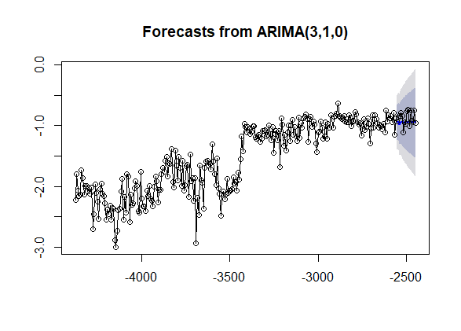

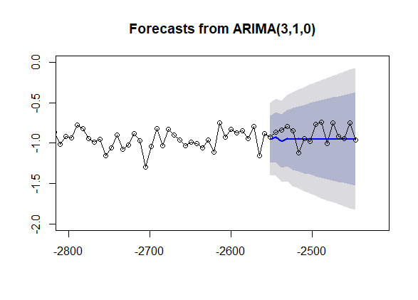

### Predicción Colgate

Se llevo a cabo la predicción de la participación de mercado de Colgate para las próximas 16 semanas (escala logarítmica). La predicción de Colgate:

| 1963 | MS | MS | MS | MS |
| --- | --- | --- | --- | --- |
| 1-4 | -1.330771 | -1.330771 | -1.330771 | -1.330771 |
| 5-8 | -1.330771 | -1.330771 | -1.330771 | -1.330771 |
| 9-12 | -1.330771 | -1.330771 | -1.330771 | -1.330771 |
| 13-16 | -1.330771 | -1.330771 | -1.330771 | -1.330771 |

**Predicción ARIMA**

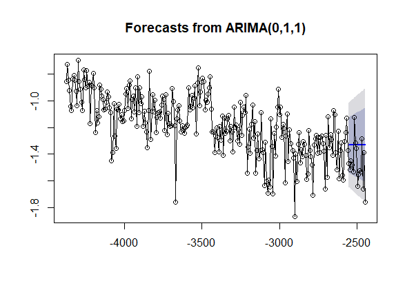

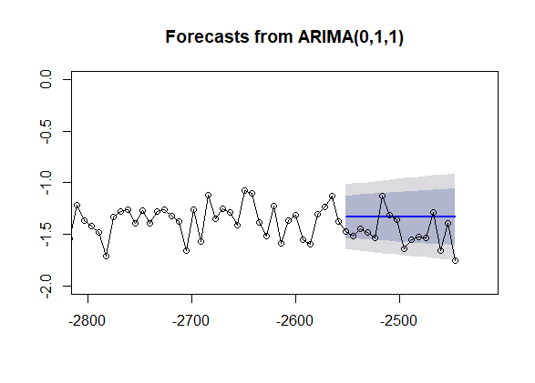

## Detección de Outliers

AL analizar las diferencias notamos un comportamiento normal (aproximadamente) por lo que una forma de buscar outliers es buscando valores en las colas.

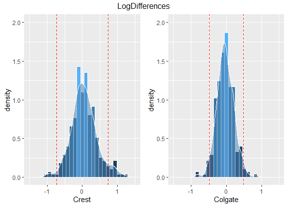

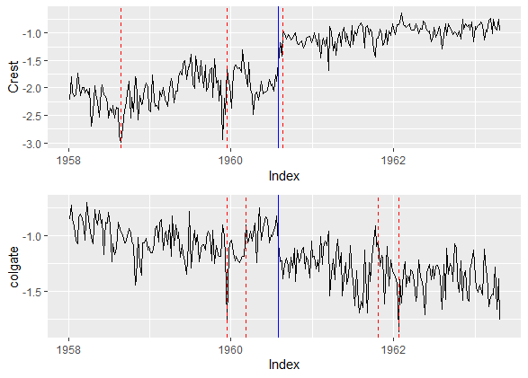

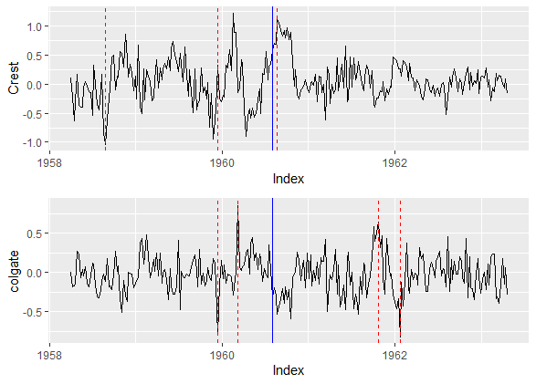

### Detección Automática

La Deteccion automatica resulta en uno de los mismos outliers antes encontrados para las dos series.

## Modelo de función de tranferencia

### Modelo Dinámico

Explicar Crest con Crest pasado y Colgate

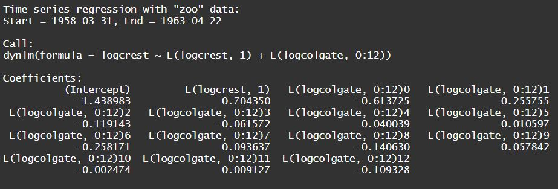

Explicar las diferencias de Crest con las de Crest pasado y Colgate

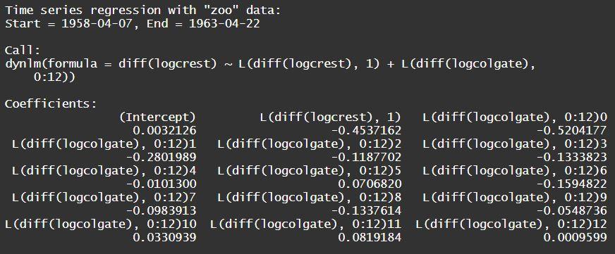

### Modelo de Función de Tranferencia

Buscamos los coeficientes significativos:

Con suficientes lags:

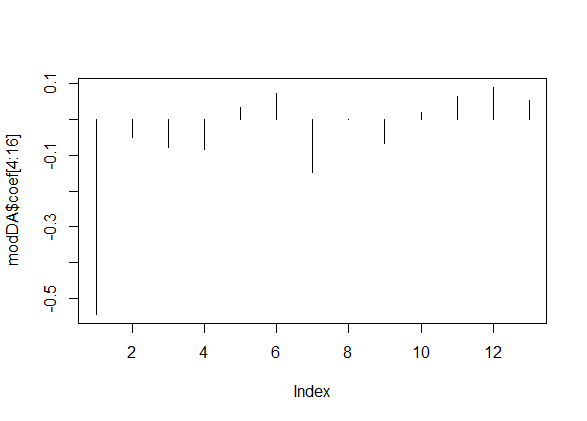

Coeficientes significativos:

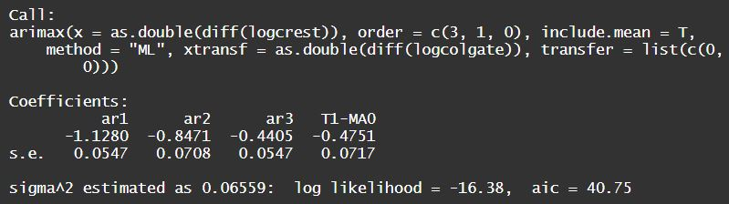

Todos son significativos ( Coeficiente entre s.e. es mayor a 2).

## Observaciones

No fue posible realizar una predicción con el modelo ARIMAX.

# Referencias

- https://stats.stackexchange.com/questions/18375/how-to-fit-an-arimax-model-with-r
- https://stackoverflow.com/questions/25224155/transfer-function-models-arimax-in-tsa
- https://rpubs.com/simasiami/378726
- https://cran.r-project.org/web/packages/TSA/TSA.pdf
- https://stats.stackexchange.com/questions/169564/arimax-prediction-using-forecast-package

# Anexos

```r
########################################################################################################
## Start Date: 18/11/2019
## End Date:   -
## Author:     José María Álvarez Silva
## School:     CUNEF
## Class:      Predicción
## Assigment:  Crest y Colgate
## Language:   Spanish
##
########################################################################################################
## Predicción
########################################################################################################
## Primas Mapfre #######################################################################################
##     ARIMAX y ARIMAS

## Propósito ###########################################################################################
##     Predicción del MS de Crest y Colgate con intervencion y sin intervención.
```

## Paquetes

```r
## Paquetes ############################################################################################
##
library(dplyr)
library(tidyverse)
library(forecast)
library(xts)
library(ggplot2)
library(zoo)
library(ggfortify)
library(skimr)
library(gridExtra)
library(ggpubr)
library(TSA)
library(Hmisc)
library(astsa)
library(dynlm)
```

## Datos

```r
## Datos ###############################################################################################
##
datos <- read.csv("data.csv")

datos$Date <- as.Date(paste(datos$Year, datos$Week, 1, sep = "-"), "%Y-%U-%u")

skim(datos)
```

|  | variable | type | stat | level | value | formatted |
| --- | --- | --- | --- | --- | --- | --- |
| 1 | Year | integer | missing | .all | 0.000000e+00 | 0 |
| 2 | Year | integer | complete | .all | 2.760000e+02 | 276 |
| 3 | Year | integer | n | .all | 2.760000e+02 | 276 |
| 4 | Year | integer | mean | .all | 1.960174e+03 | 1960.17 |
| 5 | Year | integer | sd | .all | 1.544082e+00 | 1.54 |
| 6 | Year | integer | p0 | .all | 1.958000e+03 | 1958 |
| 7 | Year | integer | p25 | .all | 1.959000e+03 | 1959 |
| 8 | Year | integer | p50 | .all | 1.960000e+03 | 1960 |
| 9 | Year | integer | p75 | .all | 1.961000e+03 | 1961 |
| 10 | Year | integer | p100 | .all | 1.963000e+03 | 1963 |

[output cut: 41 more lines]

## Análisis Exploratorio de Datos

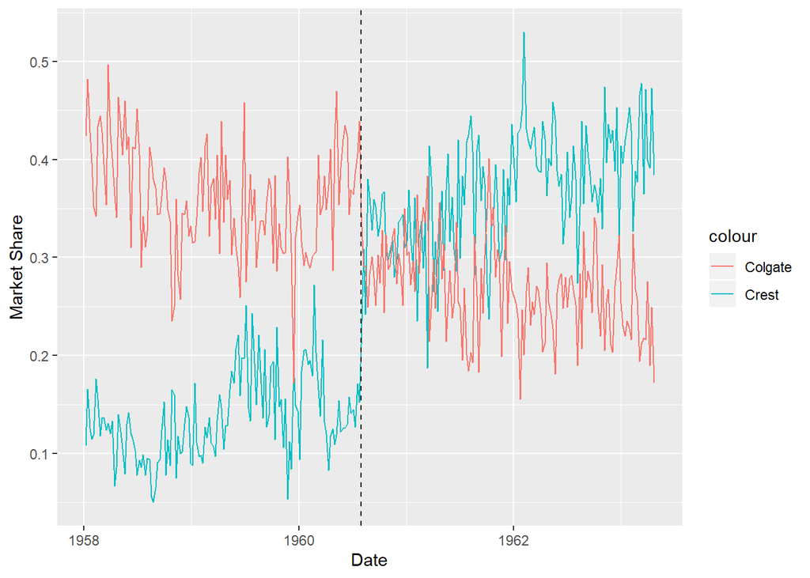

```r
## Series
ggplot(data = datos, aes(x = Date)) +
  geom_line(aes(y = Crest, colour = "Crest")) +
  geom_line(aes(y = Colgate, colour = "Colgate")) +
  ylab("Market Share") +
  geom_vline(xintercept = as.numeric(datos$Date[135]), linetype = 2) ## 1 agosto 1960
```

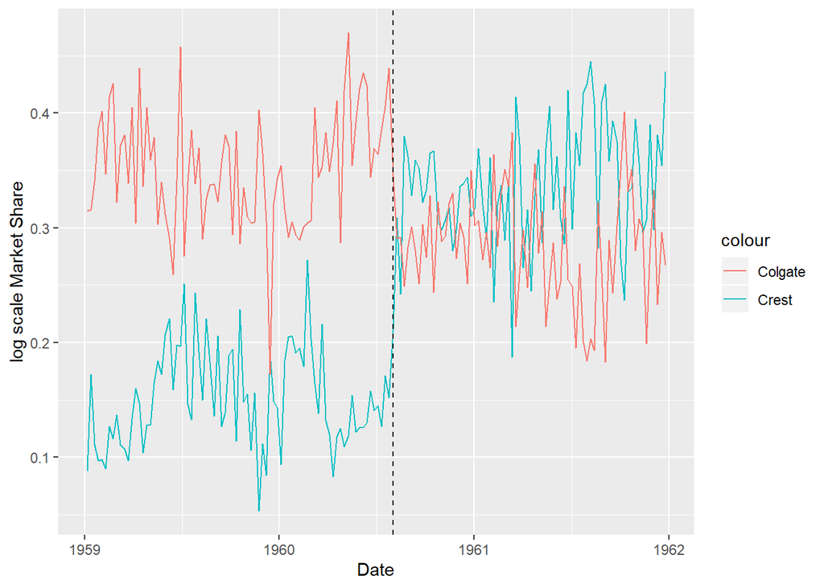

```r
ggplot(data = filter(datos, Year == 1959 | Year == 1960 | Year == 1961), aes(x = Date)) +
  geom_line(aes(y = Crest, colour = "Crest")) +
  geom_line(aes(y = Colgate, colour = "Colgate")) +
  ylab("log scale Market Share") +
  geom_vline(xintercept = as.numeric(datos$Date[135]), linetype = 2) ## 1 agosto 1960
```

### Crest

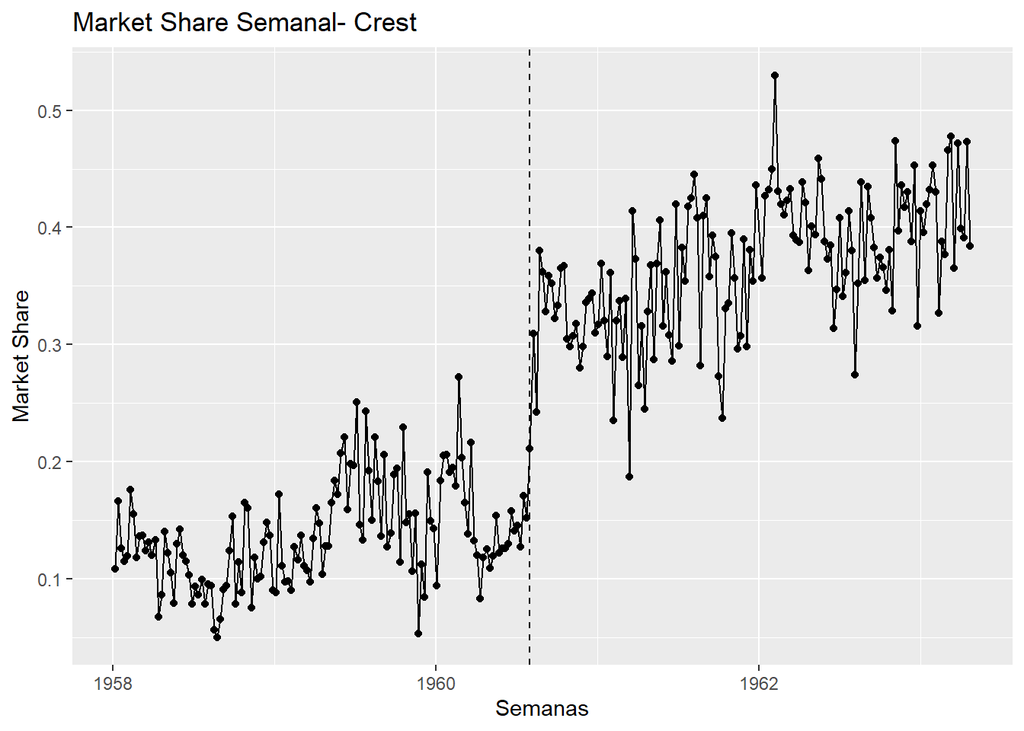

```r
## Plot Serie crest
crest = xts((datos$Crest), order.by = datos$Date)
colnames(crest) <- "Crest"
## paqueteria zoo para mejor funcionamiento
crest = as.zoo(crest$Crest)
#autoplot(crest) + ggtitle("Market Share Semanal - Crest") + xlab("Semanas") + ylab("Market Share") +
#  geom_vline(xintercept = as.numeric(datos$Date[135]), linetype = 2)

## Nuestra ts de market share de Crest de llama Crest

df_crest <- data.frame(value = as.vector(crest),
                       time = time(crest))
ggplot(df_crest) + geom_point(aes(x = time, y = value)) +
  geom_line(aes(x = time, y = value)) +
  ylab("Market Share") +
  ggtitle("Market Share Semanal- Crest") +
  xlab("Semanas") +
  geom_vline(xintercept = as.numeric(datos$Date[135]), linetype = 2)
```

#### LogCrest

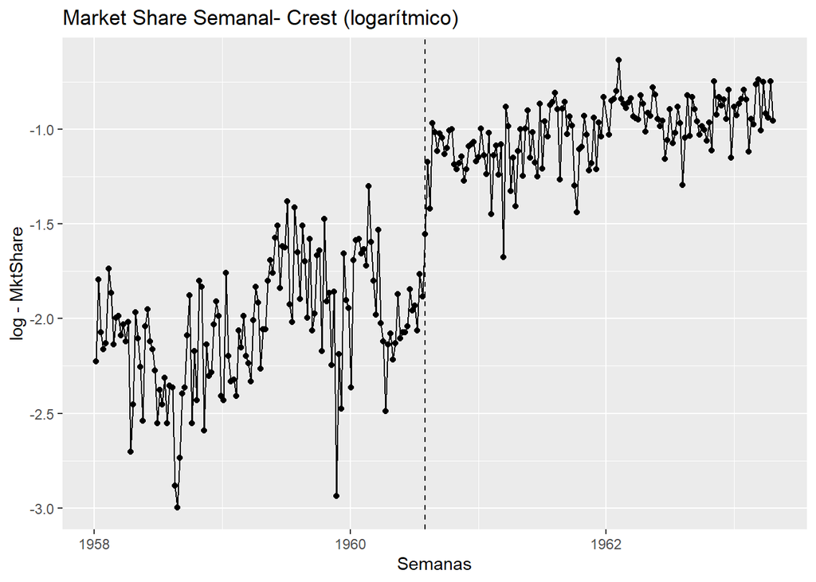

```r
## trabajamos con transformacion logaritmica
logcrest <- log(crest)
df_logcrest <- data.frame(value = as.vector(logcrest),
                          time = time(logcrest))
ggplot(df_logcrest) + geom_point(aes(x = time, y = value)) +
  geom_line(aes(x = time, y = value)) +
  ylab("log - MktShare") +
  ggtitle("Market Share Semanal- Crest (logarítmico)") +
  xlab("Semanas") +
  geom_vline(xintercept = as.numeric(datos$Date[135]), linetype = 2)
```

#### Diferenciando la serie

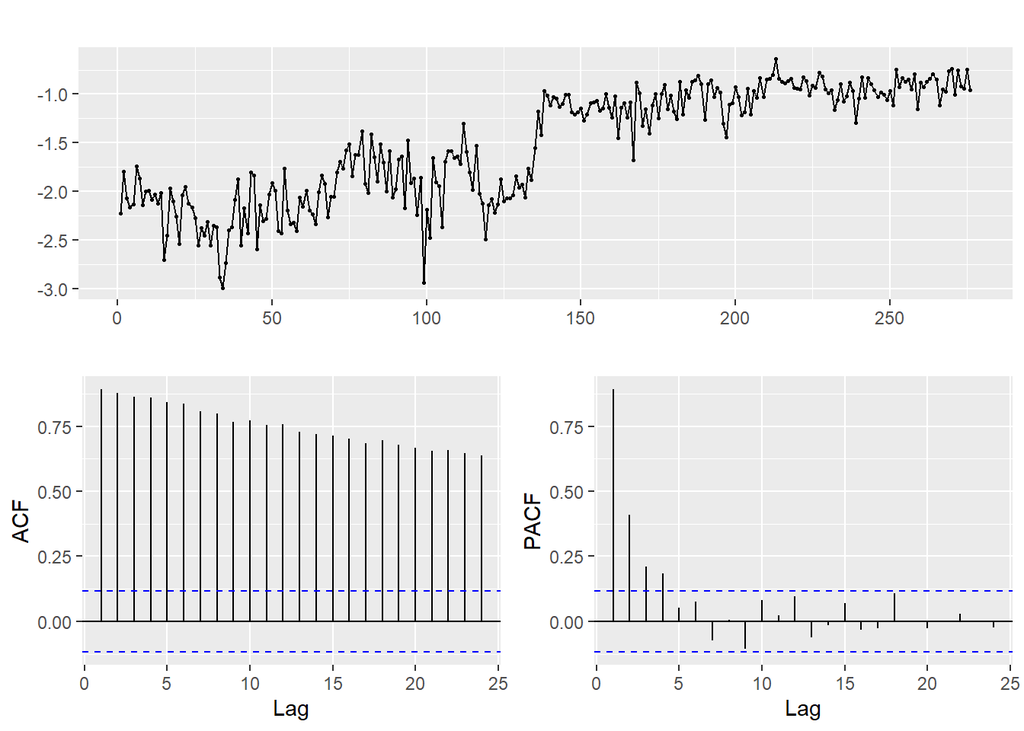

```r
## Difference
ggtsdisplay(logcrest)
```

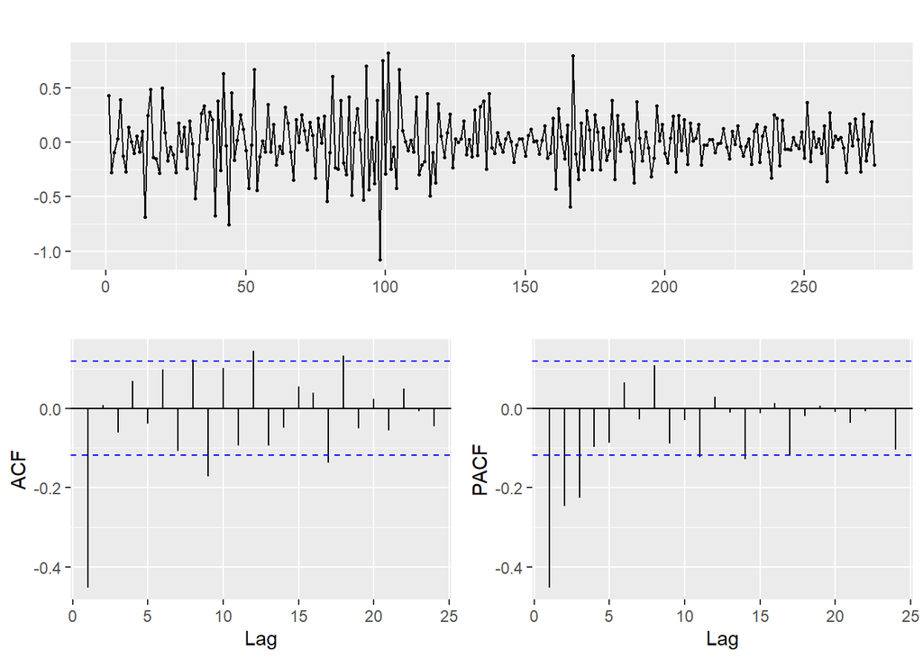

```r
ggtsdisplay(diff(logcrest))
```

```r
which(diff(logcrest) == max(diff(logcrest)))
```

```
## [1] 101
```

```r
which(diff(logcrest) == min(diff(logcrest)))
```

```
## [1] 98
```

### Colgate

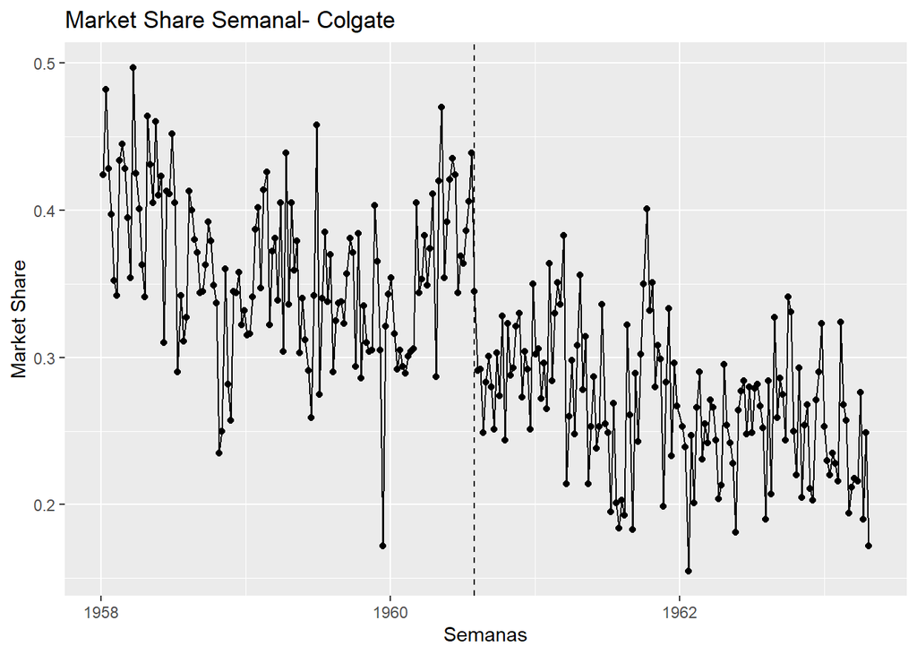

```r
#-#- Colgate #-#-#-#-#-#-#-#-#-#-#-#-#-#-#-#-#-#-#-#-#-#-#-#-

## Plot Serie colgate
colgate = xts((datos$Colgate), order.by = datos$Date)
colnames(colgate) <- "colgate"
## paqueteria zoo para mejor funcionamiento
colgate = as.zoo(colgate$colgate)
#autoplot(colgate) + ggtitle("Market Share Semanal - Colgate") + xlab("Semanas") + ylab("Market Share") +
#  geom_vline(xintercept = as.numeric(datos$Date[135]), linetype = 2)

## Nuestra ts de market share de colgate de llama colgate

df_colgate <- data.frame(value = as.vector(colgate),
                       time = time(colgate))
ggplot(df_colgate) + geom_point(aes(x = time, y = value)) +
  geom_line(aes(x = time, y = value)) +
  ylab("Market Share") +
  ggtitle("Market Share Semanal- Colgate") +
  xlab("Semanas") +
  geom_vline(xintercept = as.numeric(datos$Date[135]), linetype = 2)
```

#### LogColgate

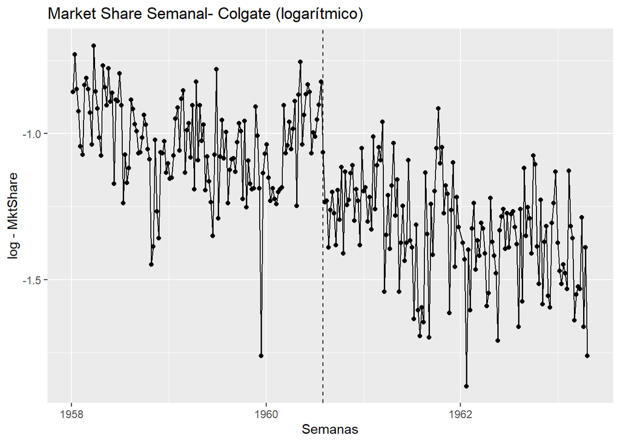

```r
## trabajamos con transformacion logaritmica
logcolgate <- log(colgate)
df_logcolgate <- data.frame(value = as.vector(logcolgate),
                            time = time(logcolgate))
ggplot(df_logcolgate) + geom_point(aes(x = time, y = value)) +
  geom_line(aes(x = time, y = value)) +
  ylab("log - MktShare") +
  ggtitle("Market Share Semanal- Colgate (logarítmico)") +
  xlab("Semanas") +
  geom_vline(xintercept = as.numeric(datos$Date[135]), linetype = 2)
```

#### Diferenciando la serie

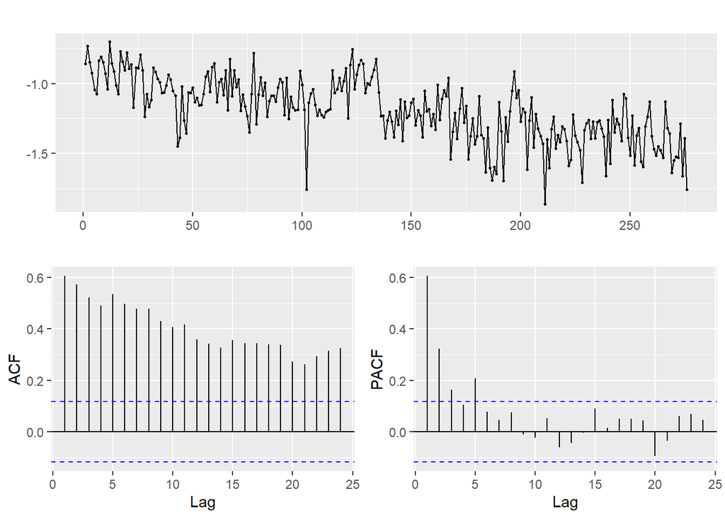

```r
## Difference
ggtsdisplay(logcolgate)
```

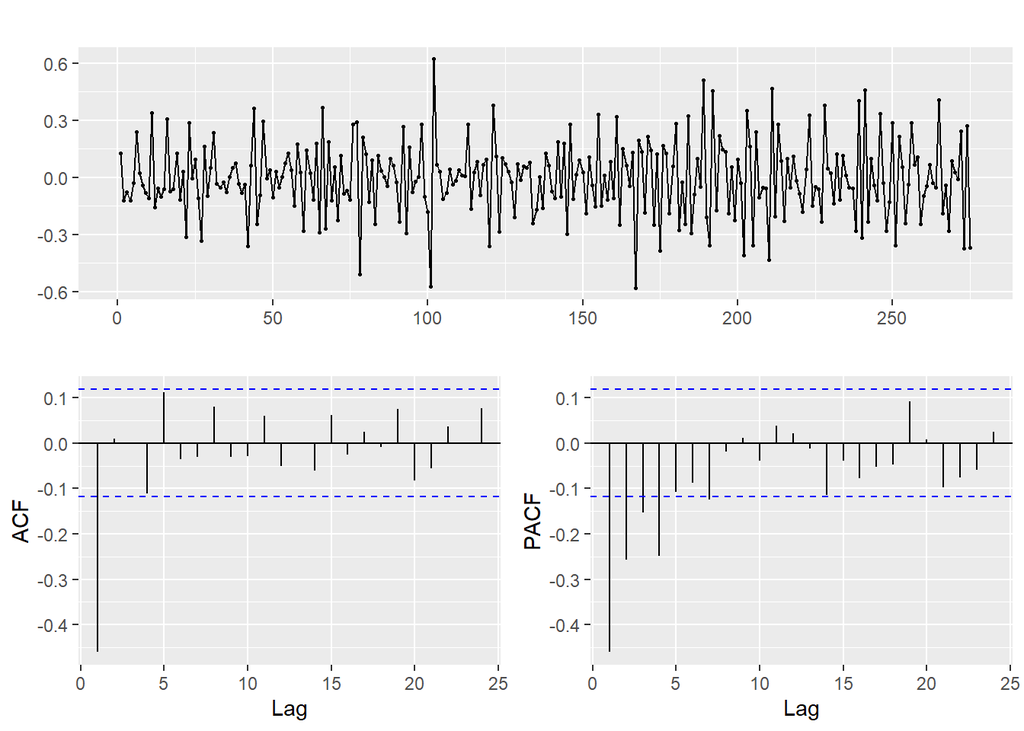

```r
ggtsdisplay(diff(logcolgate))
```

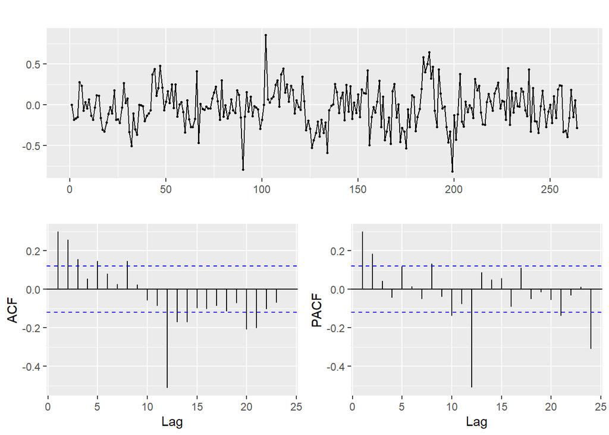

```r
ggtsdisplay(diff(logcolgate, 12))
```

```r
which(diff(logcolgate) == max(diff(logcolgate)))
```

```
## [1] 102
```

```r
which(diff(logcolgate) == min(diff(logcolgate)))
```

```
## [1] 167
```

## Detectando Outliers

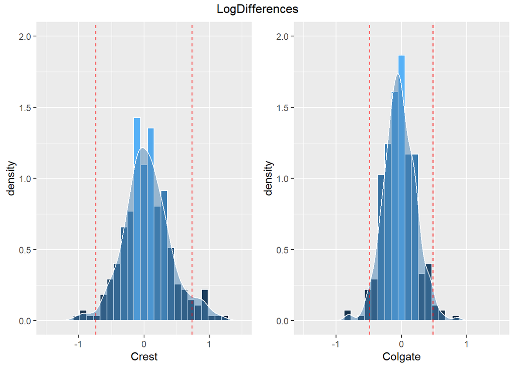

```r
#-#- Fechas Importantes #-#-#-#-#-#-#-#-#-#-#-#-#-#-#-#-#-#-#-#-#-#-#-#-


## histograms


p1 <- ggplot(data = diff(logcrest,12), aes(Crest)) +
  geom_histogram(aes(y = ..density.., fill = ..count..), color = "white") +
  xlab("Crest") +
  geom_density(fill = "steelblue", alpha = 0.5, color = "white") +
  theme(legend.position = "None")  + ylim(0,2) + xlim(-1.5,1.5) +
  geom_vline(xintercept = c(2 * sd(diff(logcrest,12)),-2 * sd(diff(logcrest,12))),
             linetype = 2, colour = "red")
p2 <- ggplot(data = diff(logcolgate,12), aes(colgate)) +
  geom_histogram(aes(y = ..density.., fill = ..count..), color = "white") +
  xlab("Colgate") +
  geom_density(fill = "steelblue", alpha = 0.5, color = "white") +
  theme(legend.position = "None")  + ylim(0,2) + xlim(-1.5,1.5) +
  geom_vline(xintercept = c(2 * sd(diff(logcolgate,12)),-2 * sd(diff(logcolgate,12))),
             linetype = 2, colour = "red")

grid.arrange(
  p1, p2,
  widths = c( 1, 1),
  top = text_grob("LogDifferences"),
  layout_matrix = rbind(c(1, 2),
                        c(1, 2))
)
```

### Outliers

```r
k = 4

which(abs(diff(logcrest,12)) > k*sd(abs(diff(logcrest,12))))
```

```
## [1]  22  99 126 127
```

```r
which(abs(diff(logcolgate,12)) > k*sd(abs(diff(logcolgate,12))))
```

```
## [1]  90 102 187 199
```

### Outlier Grafocamente

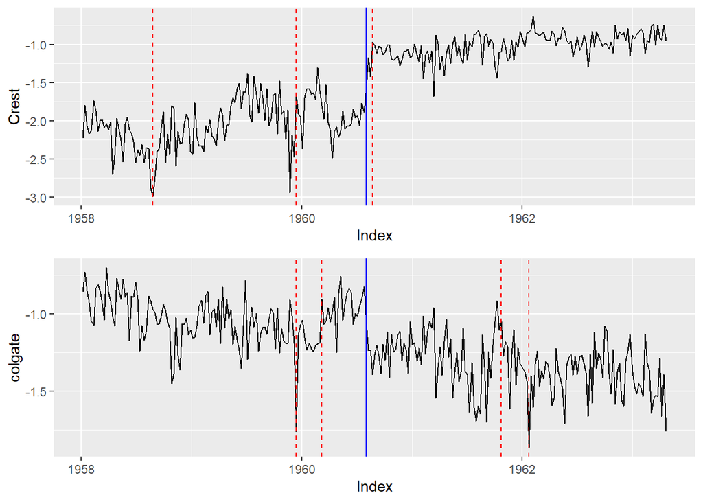

```r
## trabajando con logaritmos

p1 <- autoplot(((logcrest)))  +
  geom_vline(xintercept = as.numeric(datos$Date[126 + 12]), linetype = 2, colour = "red") +
  geom_vline(xintercept = as.numeric(datos$Date[126 + 12]), linetype = 2, colour = "red") +
  geom_vline(xintercept = as.numeric(datos$Date[90 + 12]), linetype = 2, colour = "red") +
  geom_vline(xintercept = as.numeric(datos$Date[22 + 12]), linetype = 2, colour = "red") +
  geom_vline(xintercept = as.numeric(datos$Date[135]), linetype = 1, colour = "blue")
p2 <- autoplot(((logcolgate))) +
  geom_vline(xintercept = as.numeric(datos$Date[90 + 12]), linetype = 2, colour = "red") +
  geom_vline(xintercept = as.numeric(datos$Date[102 + 12]), linetype = 2, colour = "red") +
  geom_vline(xintercept = as.numeric(datos$Date[187 + 12]), linetype = 2, colour = "red") +
  geom_vline(xintercept = as.numeric(datos$Date[199 + 12]), linetype = 2, colour = "red") +
  geom_vline(xintercept = as.numeric(datos$Date[135]), linetype = 1, colour = "blue")

grid.arrange(
  p1, p2,
  widths = c( 1, 1),
  #top = text_grob(Character),
  layout_matrix = rbind(c(1, 1),
                        c(2, 2))
)
```

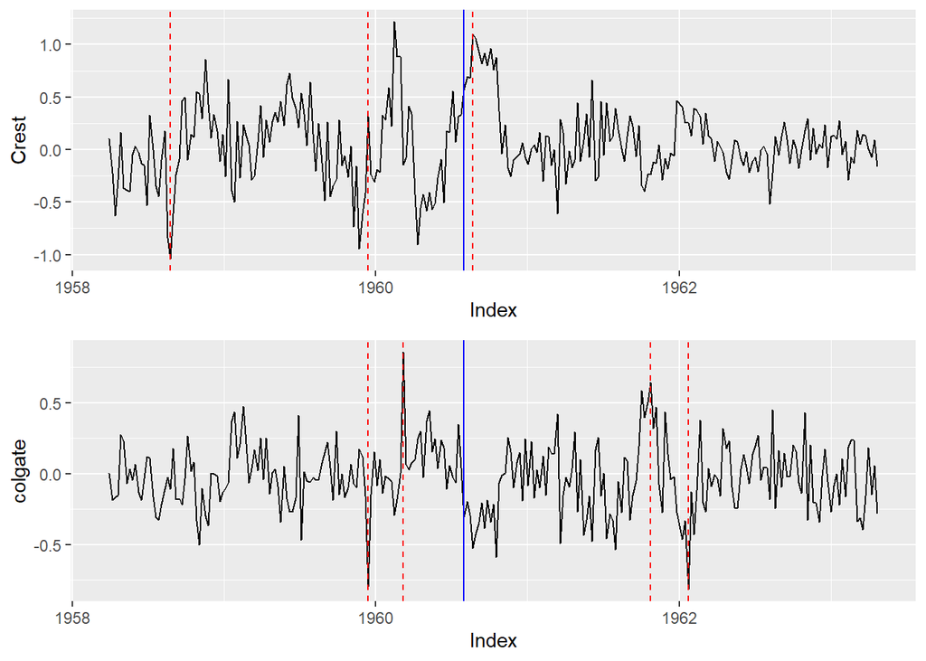

```r
## 12 lags (trimestre)

p1 <- autoplot((diff(logcrest,12)))  +
  geom_vline(xintercept = as.numeric(datos$Date[126 + 12]), linetype = 2, colour = "red") +
  geom_vline(xintercept = as.numeric(datos$Date[126 + 12]), linetype = 2, colour = "red") +
  geom_vline(xintercept = as.numeric(datos$Date[90 + 12]), linetype = 2, colour = "red") +
  geom_vline(xintercept = as.numeric(datos$Date[22 + 12]), linetype = 2, colour = "red") +
  geom_vline(xintercept = as.numeric(datos$Date[135]), linetype = 1, colour = "blue")
p2 <- autoplot((diff(logcolgate,12))) +
  geom_vline(xintercept = as.numeric(datos$Date[90 + 12]), linetype = 2, colour = "red") +
  geom_vline(xintercept = as.numeric(datos$Date[102 + 12]), linetype = 2, colour = "red") +
  geom_vline(xintercept = as.numeric(datos$Date[187 + 12]), linetype = 2, colour = "red") +
  geom_vline(xintercept = as.numeric(datos$Date[199 + 12]), linetype = 2, colour = "red") +
  geom_vline(xintercept = as.numeric(datos$Date[135]), linetype = 1, colour = "blue")

grid.arrange(
  p1, p2,
  widths = c( 1, 1),
  #top = text_grob(Character),
  layout_matrix = rbind(c(1, 1),
                        c(2, 2))
)
```

## Crest ARIMA

```r
## Crest ARIMA ########################################################################################
modCrest <- auto.arima(logcrest)
summary(modCrest)
```

```
## Series: logcrest
## ARIMA(3,1,0)
##
## Coefficients:
##           ar1      ar2      ar3
##       -0.6188  -0.3730  -0.2216
## s.e.   0.0588   0.0659   0.0588
##
## sigma^2 estimated as 0.04944:  log likelihood=23.89
## AIC=-39.78   AICc=-39.63   BIC=-25.3
##
## Training set error measures:
##                      ME      RMSE       MAE       MPE     MAPE      MASE
## Training set 0.01007853 0.2211341 0.1672474 -2.288999 11.55329 0.1103725
##                    ACF1
## Training set -0.0223424
```

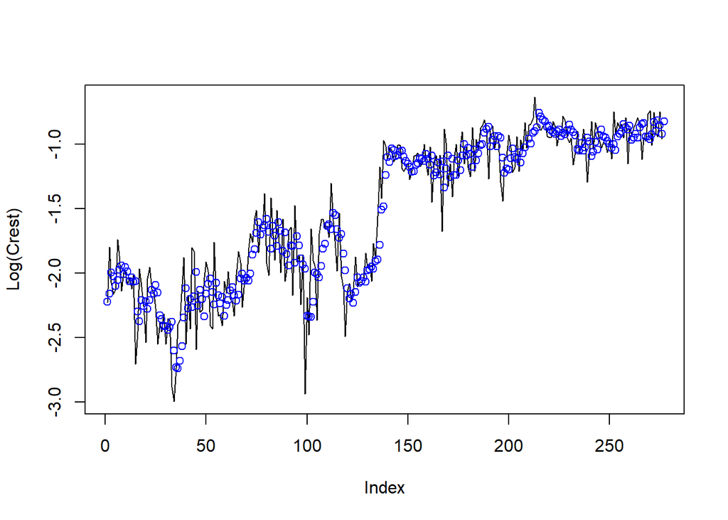

```r
plot(as.double(logcrest), ylab = "Log(Crest)", type = "l")
points(as.double(fitted(modCrest)), col = "blue")
```

### Training

```r
#- Training set     -#-#-#-#-#-#-#-#-#-#-#-#-#-#-#-#-#-#-#-#-#-#-#-#-#-#-#-#-#-#-#-#-#-#-#-#-#-#-#-#

## Select number of observation to compare forecast (16 semanas)
cOmit = 16

## Data Size
nObs = length(logcrest)

## sub_sample
oCrest <- window(logcrest,start = index(logcrest[1]),end = index(logcrest[nObs - cOmit]))

## ARIMA MODEL Automatic selection####
crest.train.arima = auto.arima(oCrest) ## lamnda cero is log transformation
summary(crest.train.arima)
```

```
## Series: oCrest
## ARIMA(3,1,0)
##
## Coefficients:
##           ar1      ar2      ar3
##       -0.6175  -0.3738  -0.2276
## s.e.   0.0605   0.0678   0.0607
##
## sigma^2 estimated as 0.05136:  log likelihood=17.59
## AIC=-27.17   AICc=-27.02   BIC=-12.93
##
## Training set error measures:
##                     ME      RMSE       MAE       MPE     MAPE     MASE
## Training set 0.0102414 0.2253215 0.1707961 -2.271995 11.48468 0.109894
##                     ACF1
## Training set -0.02012989
```

### Análisis de Residuales

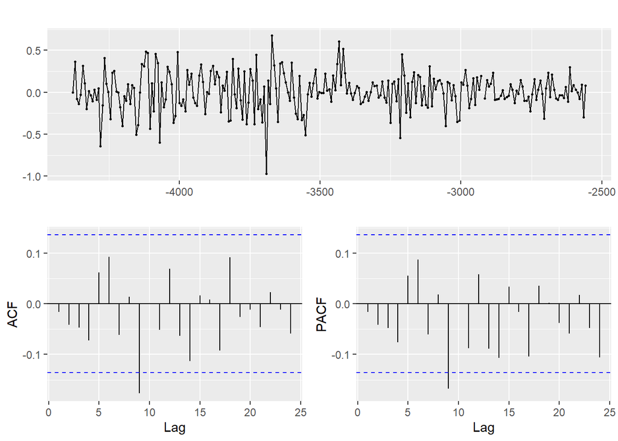

```r
#residual analysis
ggtsdisplay(crest.train.arima$residuals)
```

```r
#box-Ljung Test
Box.test(crest.train.arima$residuals,lag = 4, fitdf = 3, type = "Lj")
```

```
##
##  Box-Ljung test
##
## data:  crest.train.arima$residuals
## X-squared = 2.6221, df = 1, p-value = 0.1054
```

```r
Box.test(crest.train.arima$residuals,lag = 8, fitdf = 3, type = "Lj")
```

```
##
##  Box-Ljung test
##
## data:  crest.train.arima$residuals
## X-squared = 6.4423, df = 5, p-value = 0.2655
```

```r
Box.test(crest.train.arima$residuals,lag = 12, fitdf = 3, type = "Lj")
```

```
##
##  Box-Ljung test
##
## data:  crest.train.arima$residuals
## X-squared = 15.964, df = 9, p-value = 0.06764
```

```r
## Residuales independientes
```

### Forecast

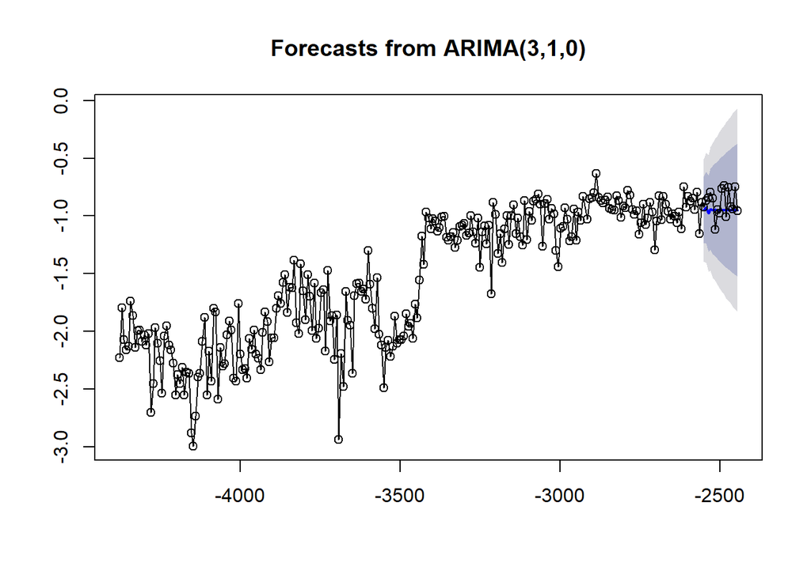

```r
plot(forecast(crest.train.arima, h = 16))
lines(window(logcrest),type = "o")
```

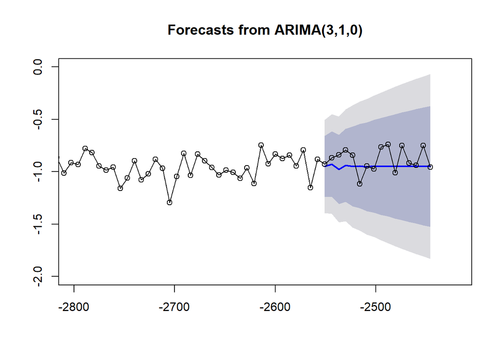

```r
plot(forecast(crest.train.arima, h = 16), xlim = c(-2800, -2420), ylim = c(-2,0))
lines(window(logcrest),type = "o")
```

```r
fcrest_arima <- forecast(crest.train.arima, h = 16) ## predecimos 16 semanas
```

### Métricas de Predición

```r
crestArimaMatrix <- matrix(c(fcrest_arima$mean[1:16], as.double(tail(logcrest,16))), ncol = 2)
crestArimaMatrix
```

```
##             [,1]       [,2]
##  [1,] -0.9493279 -0.9263411
##  [2,] -0.9266708 -0.8675006
##  [3,] -0.9769404 -0.8393297
##  [4,] -0.9390185 -0.7918632
##  [5,] -0.9488025 -0.8439701
##  [6,] -0.9454925 -1.1177951
##  [7,] -0.9525113 -0.9467499
##  [8,] -0.9471875 -0.9755101
##  [9,] -0.9486049 -0.7635696
## [10,] -0.9481219 -0.7381445
## [11,] -0.9491022 -1.0078579
## [12,] -0.9483548 -0.7507763
## [13,] -0.9485598 -0.9187939
## [14,] -0.9484894 -0.9390477
## [15,] -0.9486264 -0.7486599
## [16,] -0.9485215 -0.9571127
```

```r
## MSE
mean((crestArimaMatrix[,1] - crestArimaMatrix[,2])^2)
```

```
## [1] 0.01549924
```

```r
## MAE
mean(abs(crestArimaMatrix[,1] - crestArimaMatrix[,2]))
```

```
## [1] 0.09857839
```

```r
## Bias
mean(crestArimaMatrix[,1] - crestArimaMatrix[,2])
```

```
## [1] -0.06508188
```

## Colgate ARIMA

```r
## Colgate ARIMA ######################################################################################
modColgate <- auto.arima(logcolgate)
summary(modColgate)
```

```
## Series: logcolgate
## ARIMA(0,1,1)
##
## Coefficients:
##           ma1
##       -0.7756
## s.e.   0.0451
##
## sigma^2 estimated as 0.02574:  log likelihood=112.47
## AIC=-220.95   AICc=-220.9   BIC=-213.71
##
## Training set error measures:
##                       ME      RMSE       MAE        MPE     MAPE      MASE
## Training set -0.01086176 0.1601509 0.1244834 -0.6296119 10.53961 0.1048155
##                    ACF1
## Training set 0.04232292
```

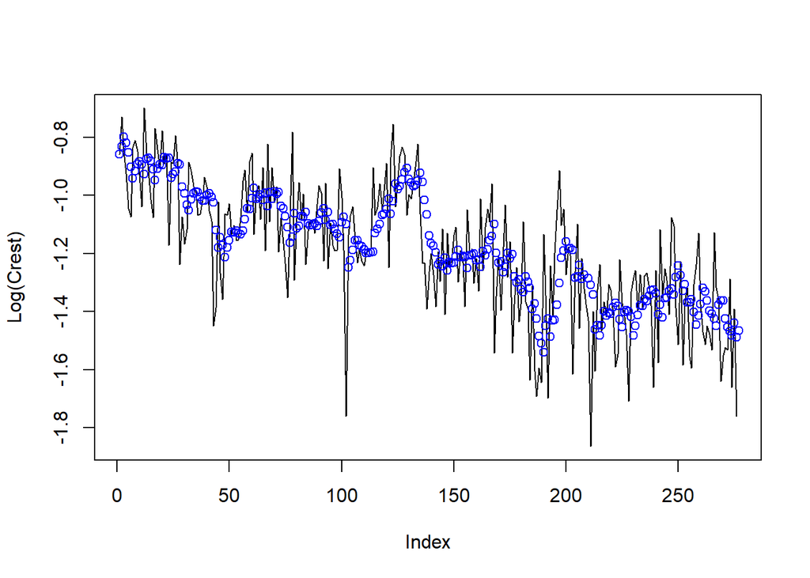

```r
plot(as.double(logcolgate), ylab = "Log(Crest)", type = "l")
points(as.double(fitted(modColgate)), col = "blue")
```

### Training

```r
#- Training set     -#-#-#-#-#-#-#-#-#-#-#-#-#-#-#-#-#-#-#-#-#-#-#-#-#-#-#-#-#-#-#-#-#-#-#-#-#-#-#-#

## Select number of observation to compare forecast (16 semanas)
cOmit = 16

## Data Size
nObs = length(logcolgate)

## sub_sample
ocolgate <- window(logcolgate,start = index(logcolgate[1]),end = index(logcolgate[nObs - cOmit]))

## ARIMA MODEL Automatic selection####
colgate.train.arima = auto.arima(ocolgate) ## lamnda cero is log transformation
summary(colgate.train.arima)
```

```
## Series: ocolgate
## ARIMA(0,1,1)
##
## Coefficients:
##           ma1
##       -0.7691
## s.e.   0.0477
##
## sigma^2 estimated as 0.02558:  log likelihood=106.73
## AIC=-209.45   AICc=-209.4   BIC=-202.33
##
## Training set error measures:
##                        ME      RMSE       MAE        MPE     MAPE
## Training set -0.007851298 0.1596299 0.1234751 -0.8500588 10.59601
##                   MASE      ACF1
## Training set 0.1055347 0.0452135
```

### Análisis de Residuales

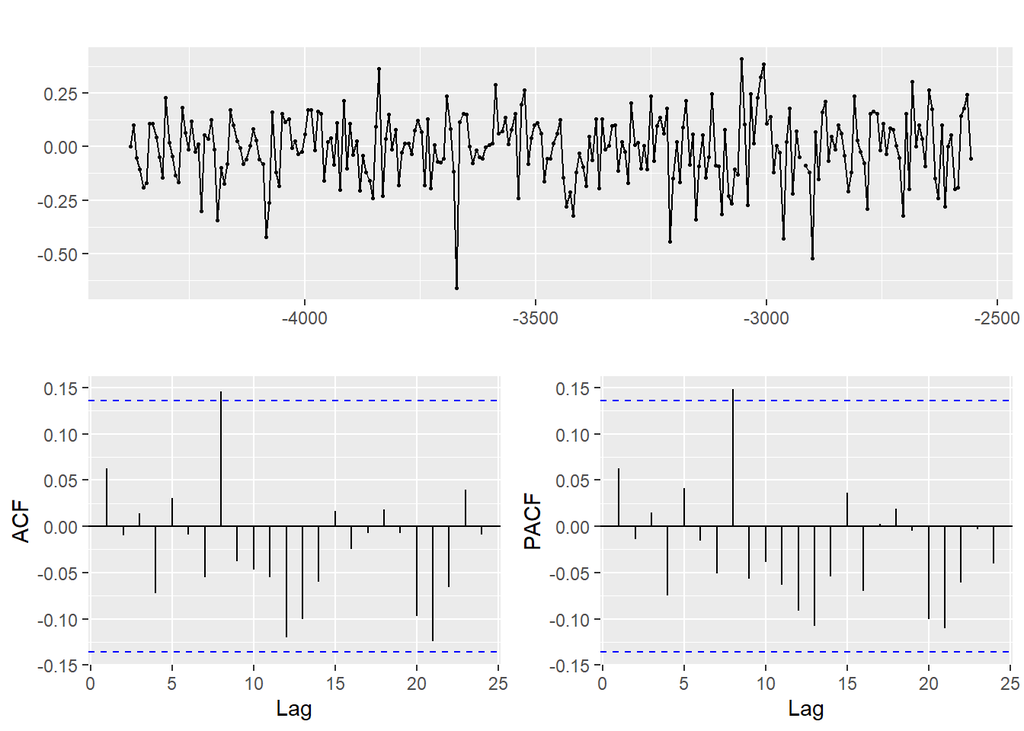

```r
#residual analysis
ggtsdisplay(colgate.train.arima$residuals)
```

```r
#box-Ljung Test
Box.test(colgate.train.arima$residuals,lag = 4, fitdf = 3, type = "Lj")
```

```
##
##  Box-Ljung test
##
## data:  colgate.train.arima$residuals
## X-squared = 2.5333, df = 1, p-value = 0.1115
```

```r
Box.test(colgate.train.arima$residuals,lag = 8, fitdf = 3, type = "Lj")
```

```
##
##  Box-Ljung test
##
## data:  colgate.train.arima$residuals
## X-squared = 4.836, df = 5, p-value = 0.4362
```

```r
Box.test(colgate.train.arima$residuals,lag = 12, fitdf = 3, type = "Lj")
```

```
##
##  Box-Ljung test
##
## data:  colgate.train.arima$residuals
## X-squared = 7.8228, df = 9, p-value = 0.5521
```

```r
## Residuales independientes
```

### Forecast

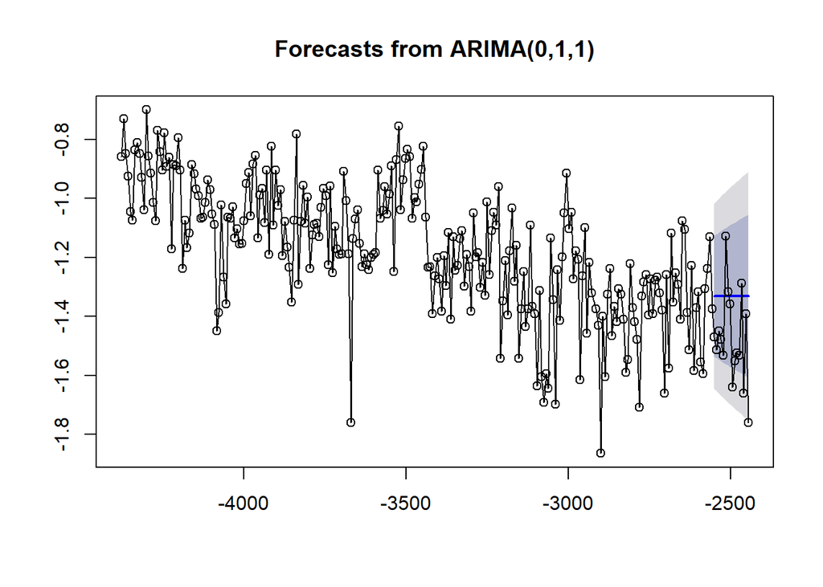

```r
plot(forecast(colgate.train.arima, h = 16))
lines(window(logcolgate),type = "o")
```

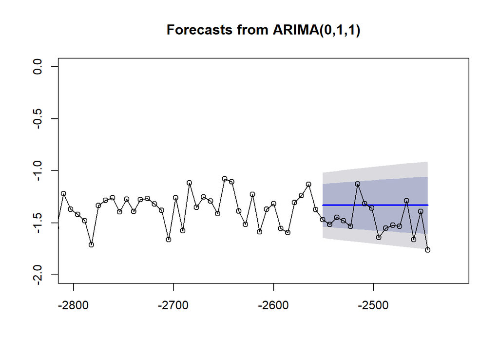

```r
plot(forecast(colgate.train.arima, h = 16), xlim = c(-2800, -2420), ylim = c(-2,0))
lines(window(logcolgate),type = "o")
```

```r
fcolgate_arima <- forecast(colgate.train.arima, h = 16) ## predecimos 16 semanas
```

### Métricas de Predición

```r
colgateArimaMatrix <- matrix(c(fcolgate_arima$mean[1:16], as.double(tail(logcolgate,16))), ncol = 2)
colgateArimaMatrix
```

```
##            [,1]      [,2]
##  [1,] -1.330771 -1.469676
##  [2,] -1.330771 -1.514128
##  [3,] -1.330771 -1.448170
##  [4,] -1.330771 -1.478410
##  [5,] -1.330771 -1.532477
##  [6,] -1.330771 -1.127012
##  [7,] -1.330771 -1.316768
##  [8,] -1.330771 -1.358679
##  [9,] -1.330771 -1.639897
## [10,] -1.330771 -1.551169
## [11,] -1.330771 -1.523260
## [12,] -1.330771 -1.532477
## [13,] -1.330771 -1.287354
## [14,] -1.330771 -1.660731
## [15,] -1.330771 -1.390302
## [16,] -1.330771 -1.760261
```

```r
## MSE
mean((colgateArimaMatrix[,1] - colgateArimaMatrix[,2])^2)
```

```
## [1] 0.04326913
```

```r
## MAE
mean(abs(colgateArimaMatrix[,1] - colgateArimaMatrix[,2]))
```

```
## [1] 0.1762993
```

```r
## Bias
mean(colgateArimaMatrix[,1] - colgateArimaMatrix[,2])
```

```
## [1] 0.1436519
```

## Outliers automáticos

```r
## Outliers ###########################################################################################
##

## Crest
detectAO(modCrest)
```

```
## [1] "No AO detected"
```

```r
detectIO(modCrest)
```

```
##              [,1] [,2]
## ind     99.000000   NA
## lambda1 -4.636878   NA
```

```r
## Colgate
detectAO(modColgate)
```

```
## [1] "No AO detected"
```

```r
detectIO(modColgate)
```

```
##               [,1] [,2]
## ind     102.000000   NA
## lambda1  -4.241699   NA
```

## Crest ARIMAX

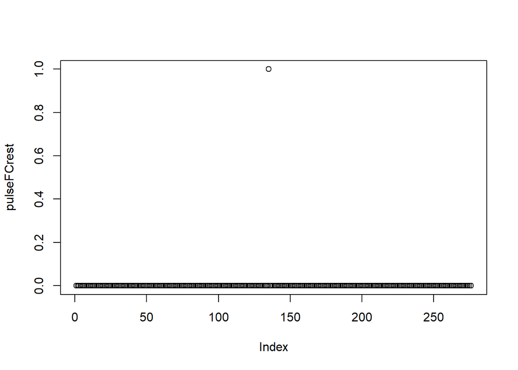

```r
## Crest ARIMAX #######################################################################################

pulseFCrest <- data.frame(ADA = 1*(seq(logcrest) == which(datos$Date == "1960-08-01")))[,1]
plot(pulseFCrest)
```

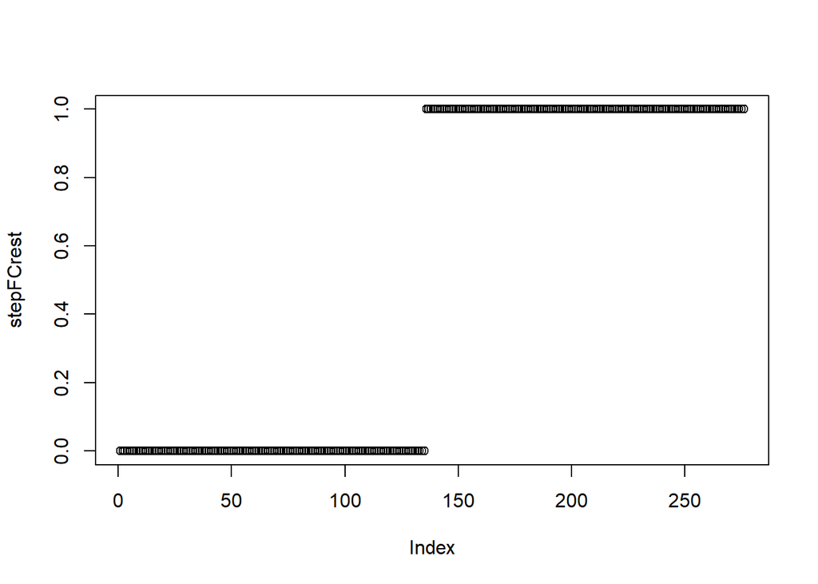

```r
stepFCrest <- data.frame(ADA = 1*(seq(logcolgate) > which(datos$Date == "1960-08-01")))[,1]
plot(stepFCrest)
```

```r
df_crest <- data.frame(pulseFCrest,stepFCrest)

## Solo step
crest.m1 = arimax(as.double(logcrest$Crest),
                  order = c(3,1,0), method = 'ML',
                  xtransf = data.frame(ADA = stepFCrest),
                  transfer = list(c(0,0)),
                  xreg = data.frame(Imp1 = 1*(seq(logcolgate) == (22 + 12)),
                                    Imp2 = 1*(seq(logcolgate) == (90 + 12)))
                  )
crest.m1
```

```
##
## Call:
## arimax(x = as.double(logcrest$Crest), order = c(3, 1, 0), xreg = data.frame(Imp1 = 1 *
##     (seq(logcolgate) == (22 + 12)), Imp2 = 1 * (seq(logcolgate) == (90 + 12))),
##     method = "ML", xtransf = data.frame(ADA = stepFCrest), transfer = list(c(0,
##         0)))
##
## Coefficients:
##           ar1      ar2      ar3     Imp1    Imp2  ADA-MA0
##       -0.6925  -0.4457  -0.2157  -0.5565  0.4882   0.5808
## s.e.   0.0611   0.0680   0.0633   0.1960  0.2095   0.1626
##
## sigma^2 estimated as 0.04485:  log likelihood = 36.36,  aic = -60.72
```

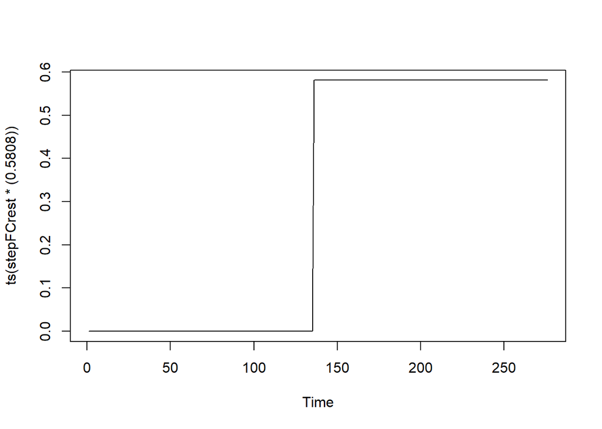

```r
plot(ts(stepFCrest*(0.5808)))
```

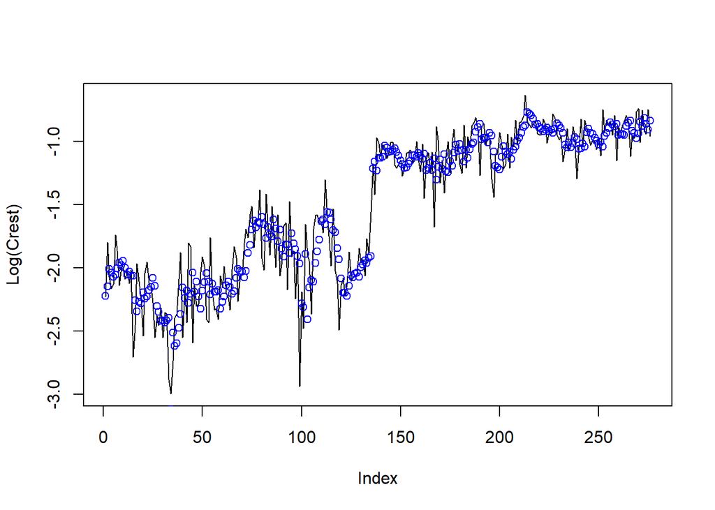

```r
plot(as.double(logcrest), ylab = "Log(Crest)", type = "l")
points(fitted(crest.m1), col = "blue")
```